# Telco customer churn prediction :

Customer churn, also known as customer attrition, refers to the phenomenon where customers cease their relationship with a company, either by ending their subscription, discontinuing their service, or switching to a competitor. This model is designed to analyze historical customer data and predict which individuals will be churning . Using a diverse range of featuresour model aims to uncover the underlying factors contributing to customer churn. By training on historical data where churn events are known, our model learns to recognize patterns indicative of potential churn risk.

# Import Libraries :

```python
import pandas as pd;
import numpy as np;
import xgboost as xgb;
from sklearn.preprocessing import LabelEncoder, StandardScaler;
from sklearn.model_selection import train_test_split , GridSearchCV;
from sklearn.tree import DecisionTreeClassifier;
from sklearn.ensemble import RandomForestClassifier;
from sklearn.metrics import roc_curve, roc_auc_score, confusion_matrix
import matplotlib.pyplot as plt
import seaborn as sns
```

- pandas will be used for data manipulation and analysis (handling data in tabular form)
- numpy will be used for numerical computing which supports multi dimensional arrays and mathematical operations
- train_test_split is used for splitting our dataset into test and train
- LabelEncoder allows the inclusion of categorical features into some of our machine learning algorithms used in this project
- We import the DecisionTreeClassifier .This class implements the decision tree algorithm for classification tasks and provides methods for training the model, making predictions, and accessing important attributes of the trained model.
- matplotlib and seaborn are libraries that we imported for visualizing data

# Load the dataset :

- We will load our dataset into dataframe using pandas

```python
df = pd.read_csv("telcocustomerbase.csv")
df.describe()#to get the statistical summary of the data
```

|  | SeniorCitizen | tenure | MonthlyCharges |
| --- | --- | --- | --- |
| count | 7043.000000 | 7043.000000 | 7043.000000 |
| mean | 0.162147 | 32.371149 | 64.761692 |
| std | 0.368612 | 24.559481 | 30.090047 |
| min | 0.000000 | 0.000000 | 18.250000 |
| 25% | 0.000000 | 9.000000 | 35.500000 |
| 50% | 0.000000 | 29.000000 | 70.350000 |
| 75% | 0.000000 | 55.000000 | 89.850000 |
| max | 1.000000 | 72.000000 | 118.750000 |

# Pre_processing :

```python
df.isna().sum()#to check for missing values
```

```
customerID          0
gender              0
SeniorCitizen       0
Partner             0
Dependents          0
tenure              0
PhoneService        0
MultipleLines       0
InternetService     0
OnlineSecurity      0
OnlineBackup        0
DeviceProtection    0
TechSupport         0
StreamingTV         0
StreamingMovies     0
Contract            0
PaperlessBilling    0
PaymentMethod       0
MonthlyCharges      0
TotalCharges        0
Churn               0
dtype: int64
```

```python
df.duplicated().sum() # check for duplicated data
df = df.drop_duplicates() # drop duplicated data
```

```python
df[df[['Partner','Dependents','PhoneService','MultipleLines','InternetService','OnlineSecurity','OnlineBackup','DeviceProtection','TechSupport','StreamingTV','StreamingMovies','Churn','Contract']].isna().any(axis=1)]#to check for missing values in the following columns
df.dropna(inplace=True)#to drop the missing values

df.info()
df.describe()
```

```
<class 'pandas.core.frame.DataFrame'>
RangeIndex: 7043 entries, 0 to 7042
Data columns (total 21 columns):
 #   Column            Non-Null Count  Dtype
---  ------            --------------  -----
 0   customerID        7043 non-null   object
 1   gender            7043 non-null   object
 2   SeniorCitizen     7043 non-null   int64
 3   Partner           7043 non-null   object
 4   Dependents        7043 non-null   object
 5   tenure            7043 non-null   int64
 6   PhoneService      7043 non-null   object
 7   MultipleLines     7043 non-null   object
 8   InternetService   7043 non-null   object
 9   OnlineSecurity    7043 non-null   object
 10  OnlineBackup      7043 non-null   object
 11  DeviceProtection  7043 non-null   object
 12  TechSupport       7043 non-null   object
 13  StreamingTV       7043 non-null   object
 14  StreamingMovies   7043 non-null   object
 15  Contract          7043 non-null   object
 16  PaperlessBilling  7043 non-null   object
 17  PaymentMethod     7043 non-null   object
 18  MonthlyCharges    7043 non-null   float64
 19  TotalCharges      7043 non-null   object
 20  Churn             7043 non-null   object
dtypes: float64(1), int64(2), object(18)
memory usage: 1.1+ MB
```

|  | SeniorCitizen | tenure | MonthlyCharges |
| --- | --- | --- | --- |
| count | 7043.000000 | 7043.000000 | 7043.000000 |
| mean | 0.162147 | 32.371149 | 64.761692 |
| std | 0.368612 | 24.559481 | 30.090047 |
| min | 0.000000 | 0.000000 | 18.250000 |
| 25% | 0.000000 | 9.000000 | 35.500000 |
| 50% | 0.000000 | 29.000000 | 70.350000 |
| 75% | 0.000000 | 55.000000 | 89.850000 |
| max | 1.000000 | 72.000000 | 118.750000 |

```python
for col in ('Partner','Dependents','PhoneService','MultipleLines','InternetService','OnlineSecurity','OnlineBackup','DeviceProtection','TechSupport','StreamingTV','StreamingMovies','Churn'):
    df[col] = LabelEncoder().fit_transform(df[col]) #converts string to int
if 'gender' in df.columns:
    df['gender'] = LabelEncoder().fit_transform(df['gender'])
print(df)
```

```
      customerID  gender  SeniorCitizen  Partner  Dependents  tenure  \
0     7590-VHVEG       0              0        1           0       1
1     5575-GNVDE       1              0        0           0      34
2     3668-QPYBK       1              0        0           0       2
3     7795-CFOCW       1              0        0           0      45
4     9237-HQITU       0              0        0           0       2
...          ...     ...            ...      ...         ...     ...
7038  6840-RESVB       1              0        1           1      24
7039  2234-XADUH       0              0        1           1      72
7040  4801-JZAZL       0              0        1           1      11
7041  8361-LTMKD       1              1        1           0       4
7042  3186-AJIEK       1              0        0           0      66

      PhoneService  MultipleLines  InternetService  OnlineSecurity  ...  \
0                0              1                0               0  ...
```

[output cut: 51 more lines]

=> this conversion will allow us to make a use of our features in order to feed the algorithm

- In this step, we'll be working on dropping NaN values of total charges & monthly charges to ensure avoid errors while training our model

```python
num_obs_before = df.shape[0]
df.loc[df['TotalCharges']==' ','TotalCharges']=np.nan #replace empty spaces with NaN
df.loc[df['MonthlyCharges']==' ','MonthlyCharges']=np.nan
df = df.dropna() #drop rows with NaN
num_obs_after = df.shape[0]#shape[0] gives the number of rows in the dataframe , 0 is the index of the rows to start from.
num_obs_dropped = num_obs_before - num_obs_after # number of observations dropped
print("Number of observations dropped:", num_obs_dropped)
```

```
Number of observations dropped: 11
```

- we will be observing the contract age for customers who left and for the ones who stayed through the following plot :

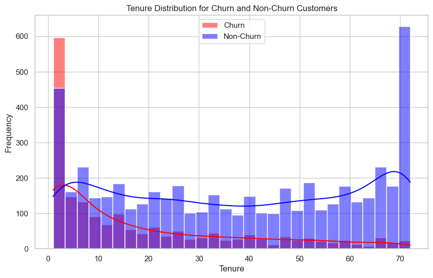

```python
churn = df[df['Churn'] == 1]
non_churn = df[df['Churn'] == 0]

sns.set(style="whitegrid")#set the background of the plot to white

# Create the plot
plt.figure(figsize=(10, 6))#set the size of the plot
sns.histplot(churn['tenure'], bins=30, color='red', alpha=0.5, label='Churn', kde=True)#plot the histogram of the tenure for churn customers bins groups the data into intervals and alpha is the transparency of the plot
sns.histplot(non_churn['tenure'], bins=30, color='blue', alpha=0.5, label='Non-Churn', kde=True)
plt.xlabel('Tenure')
plt.ylabel('Frequency')
plt.title('Tenure Distribution for Churn and Non-Churn Customers')
plt.legend()
plt.grid(True)#show grid lines
plt.show()#show the plot
```

The histogram plot illustrates the distribution of tenure (the duration of customer subscription) for both churn and non-churn customers .

- The data is segmented into two groups: churn customers (those who have terminated their subscription) and non-churn customers (those who are still subscribed).
- For churn customers, the histogram peaks at lower tenure values, indicating that a proportion of churn customers have shorter subscription durations.
- In contrast, the distribution for non-churn customers is more spread out, with a higher frequency of longer tenure values. This suggests that a larger portion of non-churn customers have been subscribed for an extended period suggesting that strategies to improve customer retention may need to focus on enhancing the early stages of the customer experience..

=> The observed differences in tenure distribution between churn and non-churn customers highlight the importance of tenure as a predictive factor for customer churn.

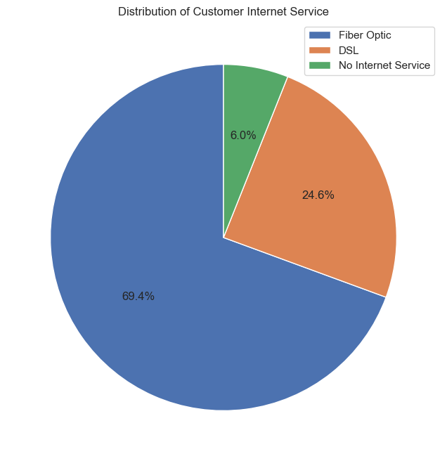

```python
churned_customers = df[df['Churn'] == 1]

internet_service_distribution = churned_customers['InternetService'].value_counts()


# Get labels based on index values


# Plot pie chart for churn count per internet service
plt.figure(figsize=(8, 8))
plt.pie(internet_service_distribution, autopct='%1.1f%%', startangle=90)
plt.title('Distribution of Customer Internet Service')
internet_service_distribution.index = ['Fiber Optic', 'DSL', 'No Internet Service']
plt.legend(internet_service_distribution.index, loc='upper right')
plt.show()
```

- the pie chart provides insight into the distribution of internet service types among churned customers, highlighting the prevalence of fiber optic services. Understanding the distribution of internet service types can inform marketing strategies, service offerings, and infrastructure investments to better cater to the diverse needs of the customer base.

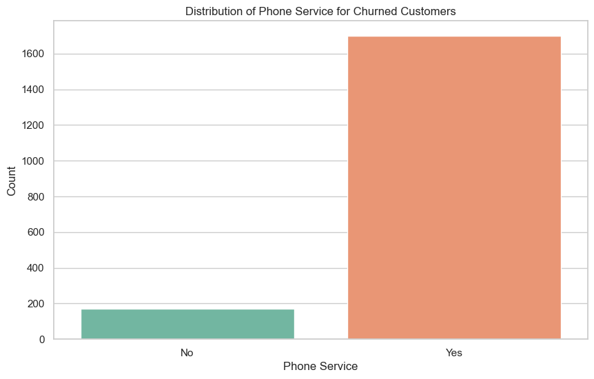

```python
churned_customers = df[df['Churn'] == 1]

# Plot bar chart for phone service distribution among churned customers
plt.figure(figsize=(10, 6))
sns.countplot(data=churned_customers, x='PhoneService', palette='Set2')
plt.title('Distribution of Phone Service for Churned Customers')
plt.xlabel('Phone Service')
plt.ylabel('Count')
plt.xticks(ticks=[0, 1], labels=['No', 'Yes'])  # Set x-axis labels
plt.show()
```

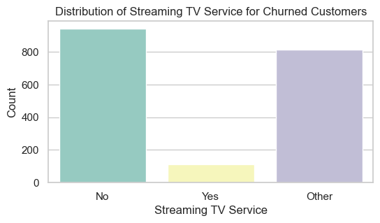

```python
# Plot bar chart for streaming TV service distribution among churned customers
churned_customers = df[df['Churn'] == 1]
plt.figure(figsize=(6, 3))
sns.countplot(data=churned_customers, x='StreamingTV', palette='Set3')
plt.title('Distribution of Streaming TV Service for Churned Customers')
plt.xlabel('Streaming TV Service')
plt.ylabel('Count')
plt.xticks(ticks=[0, 1, 2], labels=['No', 'Yes','Other'])
plt.show()
```

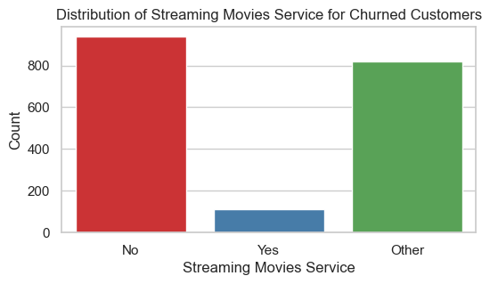

```python
# Plot bar chart for streaming movies service distribution among churned customers
churned_customers = df[df['Churn'] == 1]
plt.figure(figsize=(6, 3))
sns.countplot(data=churned_customers, x='StreamingMovies', palette='Set1')
plt.title('Distribution of Streaming Movies Service for Churned Customers')
plt.xlabel('Streaming Movies Service')
plt.ylabel('Count')
plt.xticks(ticks=[0, 1, 2], labels=['No', 'Yes','Other'])
plt.show()
```

```python
# check the top 10 of tenure rates (months):
tenure_counts = pd.DataFrame(df['tenure'].value_counts())
tenure_counts.head(10)
```

| tenure | count |
| --- | --- |
| 1 | 613 |
| 72 | 362 |
| 2 | 238 |
| 3 | 200 |
| 4 | 176 |
| 71 | 170 |
| 5 | 133 |
| 7 | 131 |
| 8 | 123 |
| 70 | 119 |

- The highest number of customers have a tenure of only 1 month, indicating a significant churn rate shortly after subscribing. This could be due to various factors such as dissatisfaction with the service, mismatched expectations, or introductory offers from competitors.

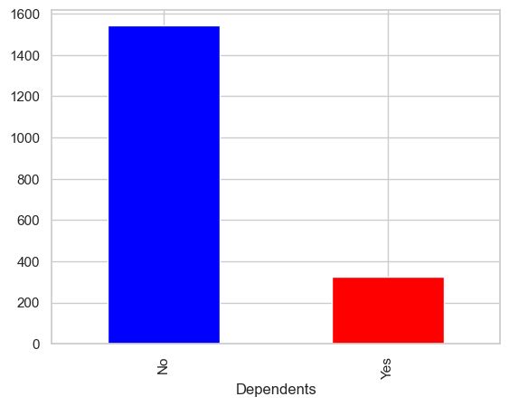

```python
churned_customers = df[df['Churn'] == 1]
churned_customers['Dependents'].value_counts().plot(kind='bar', color=['blue', 'red'])
plt.xticks(ticks=[0, 1], labels=['No', 'Yes'])
plt.show()
```

- Customers with dependents may have stronger ties to the service, leading to lower churn rates. Family considerations and stability play a role here.
- Therefore it is important to focus on retaining customers without dependents. Tailored retention efforts (such as personalized offers or improved services) can help reduce churn in this group.
- Consider segmenting marketing efforts based on the presence of dependents.

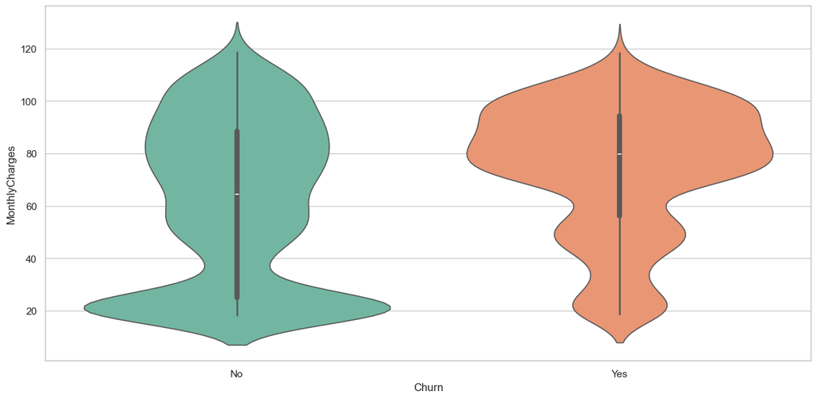

```python
plt.figure(figsize=(15,7))
sns.violinplot(x='Churn', y='MonthlyCharges', data=df, palette='Set2')
plt.xticks(ticks=[0, 1], labels=['No', 'Yes'])
plt.show()
```

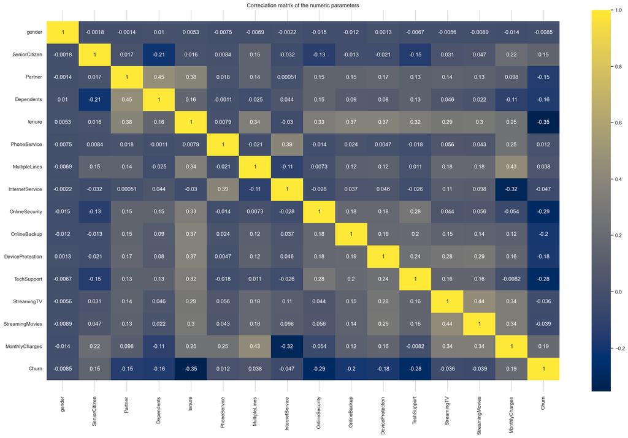

```python
# Select only numeric columns
numeric_df = df.select_dtypes(include=['number'])

# Create a heatmap of the correlation matrix
plt.figure(figsize=(25,15))
ax = sns.heatmap(numeric_df.corr(), annot=True, cmap='cividis')
plt.title("Correclation matrix of the numeric parameters")
bottom, top = ax.get_ylim()
ax.set_ylim(bottom + 0.5, top - 0.5);
plt.yticks(rotation=0);
```

# Train/Test our model :

### Decision Tree Classifier :

a decision tree classifier offers several advantages. Firstly, decision trees are intuitive and easy to interpret, making them suitable for explaining the factors that contribute to customer churn. This interpretability is crucial for businesses to understand the underlying patterns driving customer behavior.Additionally, decision trees are robust to outliers and do not require extensive data preprocessing, saving time and effort in the model development process. Furthermore, decision trees can capture non-linear relationships between predictors and the target variable, allowing for more accurate predictions in complex churn scenarios.

- simplicity, interpretability, and flexibility made decision tree classifier a suitable tool for predicting churn
- We will be initializing our Decision Tree Classifier and train the model on the training data :

```python
df_encoded = pd.get_dummies(df)#encode the categorical data to numerical data so that the model can understand it


y = df_encoded['Churn'] #target variable that we want to predict
x = df_encoded.drop('Churn', axis=1)

x_train, x_test, y_train, y_test = train_test_split(x, y, test_size=0.2, random_state=42)

tree_clf = DecisionTreeClassifier(max_depth=4, random_state=42)
tree_clf.fit(x_train, y_train)

x_test.info() #to get the information of the test data
x_test.head()
```

```
<class 'pandas.core.frame.DataFrame'>
Index: 1407 entries, 2481 to 3984
Columns: 13586 entries, gender to TotalCharges_999.9
dtypes: bool(13571), float64(1), int32(12), int64(2)
memory usage: 18.3 MB
```

|  | gender | SeniorCitizen | Partner | Dependents | tenure | PhoneService | MultipleLines | InternetService | OnlineSecurity | OnlineBackup | ... | TotalCharges_995.35 | TotalCharges_996.45 | TotalCharges_996.85 | TotalCharges_996.95 | TotalCharges_997.65 | TotalCharges_997.75 | TotalCharges_998.1 | TotalCharges_999.45 | TotalCharges_999.8 | TotalCharges_999.9 |
| --- | --- | --- | --- | --- | --- | --- | --- | --- | --- | --- | --- | --- | --- | --- | --- | --- | --- | --- | --- | --- | --- |
| 2481 | 1 | 1 | 1 | 0 | 61 | 1 | 2 | 2 | 1 | 1 | ... | False | False | False | False | False | False | False | False | False | False |
| 6784 | 0 | 0 | 0 | 0 | 19 | 1 | 2 | 2 | 1 | 1 | ... | False | False | False | False | False | False | False | False | False | False |
| 6125 | 1 | 0 | 1 | 0 | 13 | 1 | 2 | 1 | 0 | 0 | ... | False | False | False | False | False | False | False | False | False | False |
| 3052 | 1 | 0 | 1 | 0 | 37 | 1 | 2 | 0 | 2 | 0 | ... | False | False | False | False | False | False | False | False | False | False |
| 4099 | 0 | 0 | 0 | 0 | 6 | 0 | 1 | 0 | 2 | 0 | ... | False | False | False | False | False | False | False | False | False | False |

5 rows × 13586 columns

- The next phase is meant for the prediction on the test data

```python
y_pred = tree_clf.predict(x_test) #predict the target variable using the test data
```

- as the prediction phase is done we'll be moving to the model evaluation phase :

**Evaluation of the model using decision tree classifier:**

A confusion matrix is a valuable tool for evaluating the performance of a classification model. It provides a comprehensive summary of the model's predictions by comparing them to the actual labels in the test dataset. The matrix is organized into four quadrants: true positives (TP), true negatives (TN), false positives (FP), and false negatives (FN). In the context of churn prediction, true positives represent cases where the model correctly identifies customers who churned, while true negatives denote cases where the model correctly identifies customers who did not churn. On the other hand, false positives occur when the model incorrectly predicts churn for customers who actually did not churn, and false negatives occur when the model incorrectly predicts non-churn for customers who actually churned.

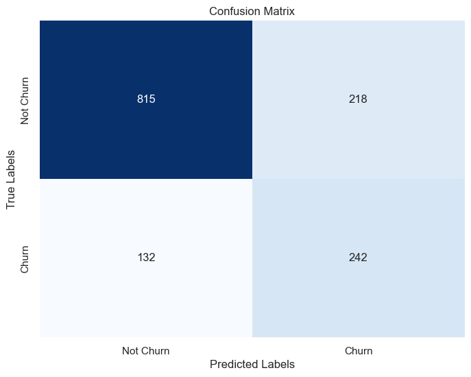

```python
conf_matrix = confusion_matrix(y_test, y_pred)
class_labels = ['Not Churn', 'Churn']

plt.figure(figsize=(8, 6))
sns.heatmap(conf_matrix, annot=True, fmt='d', cmap='Blues', cbar=False , xticklabels=class_labels, yticklabels=class_labels)
plt.xlabel('Predicted Labels')
plt.ylabel('True Labels')
plt.title('Confusion Matrix')
plt.show()
```

the goal is to minimize false predictions (both false positives and false negatives) while maximizing true predictions.

The Receiver Operating Characteristic (ROC) curve is a graphical representation used to evaluate the performance of a classification model at various classification thresholds. It illustrates the diagnostic ability of a binary classifier system as its discrimination threshold is varied.

we will use the roc curve to evaluate the model which will represents the ability of the model to discriminate between positive and negative classes along with the auc score which is interpreted as the probability that the model will rank a randomly chosen positive example higher than a randomly chosen negative example :

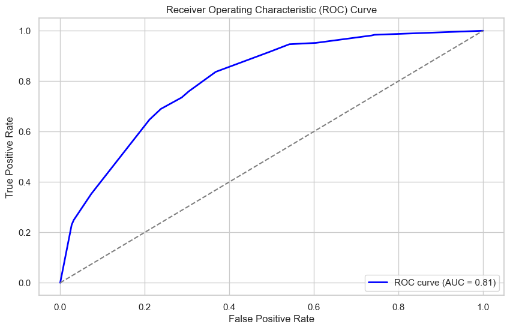

```python
y_prob = tree_clf.predict_proba(x_test)[:,1] #predict the probability of the target variable using the test data to get the roc curve
fpr, tpr, thresholds = roc_curve(y_test, y_prob)
auc = roc_auc_score(y_test, y_prob)
# Plot ROC curve
plt.figure(figsize=(10, 6))
plt.plot(fpr, tpr, color='blue', lw=2, label='ROC curve (AUC = %0.2f)' % auc)
plt.plot([0, 1], [0, 1], color='gray', linestyle='--')
plt.xlabel('False Positive Rate')
plt.ylabel('True Positive Rate')
plt.title('Receiver Operating Characteristic (ROC) Curve')
plt.legend(loc='lower right')
plt.show()
```

Customer churn prediction typically involves binary classification tasks where the model predicts whether a customer will churn (positive class) or not (negative class). The ROC curve provides a comprehensive evaluation of the model's ability to discriminate between churn and non-churn cases by considering various classification thresholds.

the target variable or the positive class in the ROC curve is typically the event of interest, which is "churn" or "customer leaving." This means that the model's performance is evaluated based on its ability to correctly classify customers who churn (true positives)

**Hyper-tunning** :

The objective of hyperparameter tuning is to optimize the performance of the machine learning model by adjusting these hyperparameters (settings that govern the learning process of the algorithm).This optimization is typically done through a systematic search over a predefined range of hyperparameter values, guided by a performance metric such as accuracy, precision, recall, or the area under the ROC curve (AUC).

We will perform here a Grid search and k-fold cross validation for Decision Tree classifier emphasizing the effect of hyper-parameter tunning on our model's performance :

```python
param_grid = {
    'max_depth': [None, 5],
    'min_samples_split': [2, 5],
    'min_samples_leaf': [1, 2]
}

# Create a decision tree classifier
tree_clf = DecisionTreeClassifier(random_state=42)

# Create GridSearchCV instance
grid_search = GridSearchCV(estimator=tree_clf, param_grid=param_grid, scoring='roc_auc', cv=5, verbose=1)

# Fit the GridSearchCV object to the data
grid_search.fit(x_train, y_train)

# Get the best parameters and best AUC score
best_params = grid_search.best_params_
best_auc = grid_search.best_score_

print("Best parameters:", best_params)
print("Best AUC score:", best_auc)
```

```
Fitting 5 folds for each of 8 candidates, totalling 40 fits
Best parameters: {'max_depth': 5, 'min_samples_leaf': 2, 'min_samples_split': 5}
Best AUC score: 0.8298610380040005
```

there's an 83% chance that the model will correctly predict churn for a randomly selected pair of churned and non-churned customers. This level of predictive performance indicates that the model is effective in identifying potential churners and can be valuable for informing churn prevention strategies.

### Random Forest Classifier :

Next, we will be moving to another algorithm known as the Random Forest Classifier; This algorithm is a powerful ensemble learning technique that utilizes multiple decision trees to make predictions. Random Forest can handle large and complex datasets effectively, making it suitable for analyzing customer data from various sources. By aggregating the predictions of multiple decision trees, Random Forest reduces overfitting and provides more robust predictions compared to individual decision trees. This is particularly beneficial in churn prediction, where the goal is to accurately identify customers at risk of leaving the service.

- We will be initializing our Random Forest Classifier and train the model on the training data and make predictions :

```python
rf_clf = RandomForestClassifier(max_depth=4, random_state=42)
rf_clf.fit(x_train, y_train)
y_pred = rf_clf.predict(x_test)

x_test.info() #to get the information of the test data
x_test.head()
```

```
<class 'pandas.core.frame.DataFrame'>
Index: 1407 entries, 2481 to 3984
Columns: 13586 entries, gender to TotalCharges_999.9
dtypes: bool(13571), float64(1), int32(12), int64(2)
memory usage: 18.3 MB
```

|  | gender | SeniorCitizen | Partner | Dependents | tenure | PhoneService | MultipleLines | InternetService | OnlineSecurity | OnlineBackup | ... | TotalCharges_995.35 | TotalCharges_996.45 | TotalCharges_996.85 | TotalCharges_996.95 | TotalCharges_997.65 | TotalCharges_997.75 | TotalCharges_998.1 | TotalCharges_999.45 | TotalCharges_999.8 | TotalCharges_999.9 |
| --- | --- | --- | --- | --- | --- | --- | --- | --- | --- | --- | --- | --- | --- | --- | --- | --- | --- | --- | --- | --- | --- |
| 2481 | 1 | 1 | 1 | 0 | 61 | 1 | 2 | 2 | 1 | 1 | ... | False | False | False | False | False | False | False | False | False | False |
| 6784 | 0 | 0 | 0 | 0 | 19 | 1 | 2 | 2 | 1 | 1 | ... | False | False | False | False | False | False | False | False | False | False |
| 6125 | 1 | 0 | 1 | 0 | 13 | 1 | 2 | 1 | 0 | 0 | ... | False | False | False | False | False | False | False | False | False | False |
| 3052 | 1 | 0 | 1 | 0 | 37 | 1 | 2 | 0 | 2 | 0 | ... | False | False | False | False | False | False | False | False | False | False |
| 4099 | 0 | 0 | 0 | 0 | 6 | 0 | 1 | 0 | 2 | 0 | ... | False | False | False | False | False | False | False | False | False | False |

5 rows × 13586 columns

**Evaluation of the model using random forest classifier:**

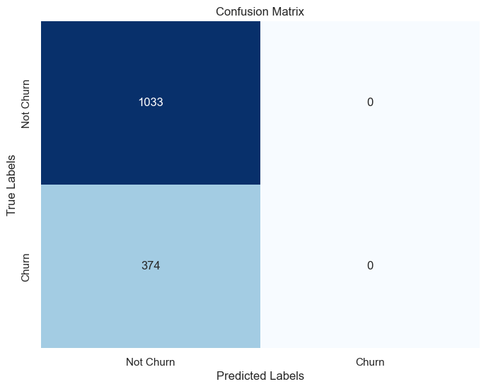

```python
conf_matrix = confusion_matrix(y_test, y_pred)
class_labels = ['Not Churn', 'Churn']

plt.figure(figsize=(8, 6))
sns.heatmap(conf_matrix, annot=True, fmt='d', cmap='Blues', cbar=False , xticklabels=class_labels, yticklabels=class_labels)
plt.xlabel('Predicted Labels')
plt.ylabel('True Labels')
plt.title('Confusion Matrix')
plt.show()
```

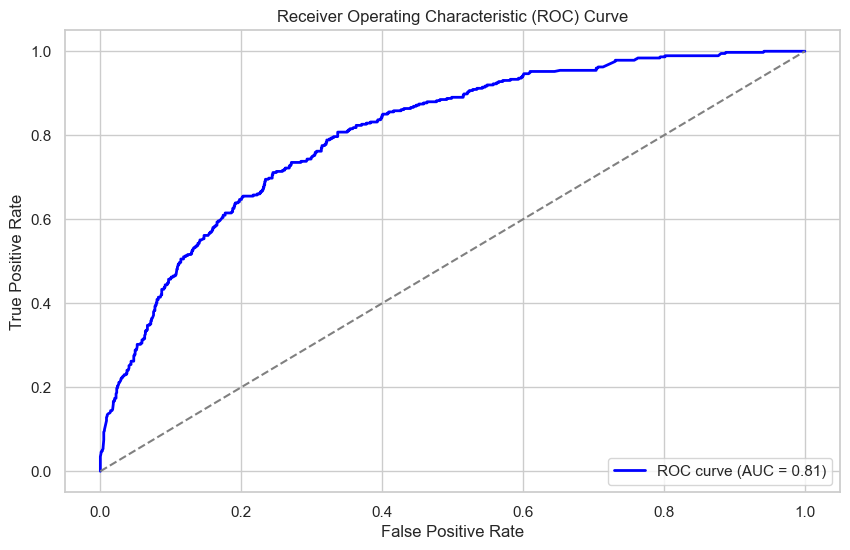

```python
y_prob = rf_clf.predict_proba(x_test)[:,1] #predict the probability of the target variable using the test data to get the roc curve
fpr, tpr, thresholds = roc_curve(y_test, y_prob)
auc = roc_auc_score(y_test, y_prob)
# Plot ROC curve
plt.figure(figsize=(10, 6))
plt.plot(fpr, tpr, color='blue', lw=2, label='ROC curve (AUC = %0.2f)' % auc)
plt.plot([0, 1], [0, 1], color='gray', linestyle='--')
plt.xlabel('False Positive Rate')
plt.ylabel('True Positive Rate')
plt.title('Receiver Operating Characteristic (ROC) Curve')
plt.legend(loc='lower right')
plt.show()
```

the Decision Tree and Random Forest, exhibit the same AUC score of 0.81, it suggests that they perform similarly in terms of discriminating between positive and negative classes. In other words, both models are equally effective at ranking the instances correctly, distinguishing between churn and non-churn instances. However, it's essential to note that although the AUC scores are the same, the underlying mechanisms of the models differ significantly.

**Hyper-tunning of the random forest classifier** :

```python
param_grid = {
    'n_estimators': [50, 100],
    'max_depth': [None, 5],
    'min_samples_split': [2, 5],
    'min_samples_leaf': [1, 2]
}

# Create a decision tree classifier
rf_clf = RandomForestClassifier(random_state=42)

# Create GridSearchCV instance
grid_search = GridSearchCV(estimator=rf_clf, param_grid=param_grid, scoring='roc_auc', cv=5, verbose=1)

# Fit the GridSearchCV object to the data
grid_search.fit(x_train, y_train)

# Get the best parameters and best AUC score
best_params = grid_search.best_params_
best_auc = grid_search.best_score_

print("Best parameters:", best_params)
print("Best AUC score:", best_auc)
```

```
Fitting 5 folds for each of 16 candidates, totalling 80 fits
Best parameters: {'max_depth': None, 'min_samples_leaf': 1, 'min_samples_split': 2, 'n_estimators': 100}
Best AUC score: 0.8413638682614366
```

The Random Forest model achieved an improved AUC score of 0.8414 compared to the Decision Tree model's AUC score of 0.8299. This enhancement can be attributed to the ensemble nature of Random Forest. This increased complexity and diversity in the ensemble contribute to capturing more intricate patterns in the data, resulting in better predictive performance as indicated by the higher AUC score .

### XGBoost :

XGBoost, short for eXtreme Gradient Boosting, is a powerful machine learning algorithm known for its efficiency and effectiveness in handling structured/tabular data. It utilizes gradient boosting, incorporating regularization techniques,to prevent overfitting while improving generalization. With built-in cross-validation methods and support for custom loss functions, XGBoost offers flexibility and often achieves outstanding performance in predictive modeling tasks.

```python
xgb_clf = xgb.XGBClassifier(max_depth=4, random_state=42)
# Fit the model
xgb_clf.fit(x_train, y_train)
# Predict the target variable
y_pred = xgb_clf.predict(x_test)
x_test.info() #to get the information of the test data
x_test.head()
```

```
<class 'pandas.core.frame.DataFrame'>
Index: 1407 entries, 2481 to 3984
Columns: 13586 entries, gender to TotalCharges_999.9
dtypes: bool(13571), float64(1), int32(12), int64(2)
memory usage: 18.3 MB
```

|  | gender | SeniorCitizen | Partner | Dependents | tenure | PhoneService | MultipleLines | InternetService | OnlineSecurity | OnlineBackup | ... | TotalCharges_995.35 | TotalCharges_996.45 | TotalCharges_996.85 | TotalCharges_996.95 | TotalCharges_997.65 | TotalCharges_997.75 | TotalCharges_998.1 | TotalCharges_999.45 | TotalCharges_999.8 | TotalCharges_999.9 |
| --- | --- | --- | --- | --- | --- | --- | --- | --- | --- | --- | --- | --- | --- | --- | --- | --- | --- | --- | --- | --- | --- |
| 2481 | 1 | 1 | 1 | 0 | 61 | 1 | 2 | 2 | 1 | 1 | ... | False | False | False | False | False | False | False | False | False | False |
| 6784 | 0 | 0 | 0 | 0 | 19 | 1 | 2 | 2 | 1 | 1 | ... | False | False | False | False | False | False | False | False | False | False |
| 6125 | 1 | 0 | 1 | 0 | 13 | 1 | 2 | 1 | 0 | 0 | ... | False | False | False | False | False | False | False | False | False | False |
| 3052 | 1 | 0 | 1 | 0 | 37 | 1 | 2 | 0 | 2 | 0 | ... | False | False | False | False | False | False | False | False | False | False |
| 4099 | 0 | 0 | 0 | 0 | 6 | 0 | 1 | 0 | 2 | 0 | ... | False | False | False | False | False | False | False | False | False | False |

5 rows × 13586 columns

**Evaluation of the model using XGBoost classifier:**

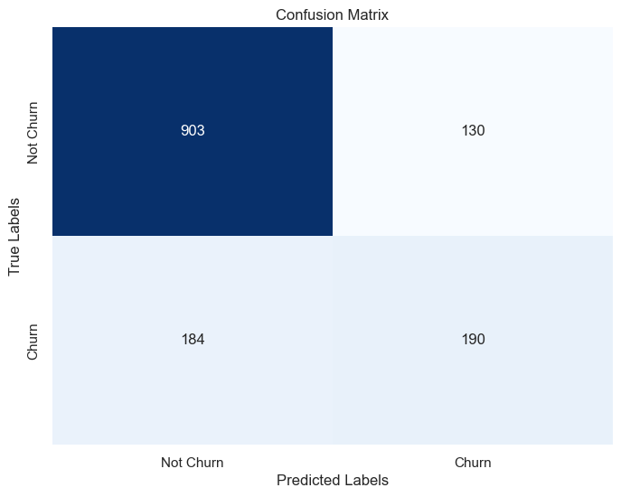

```python
conf_matrix = confusion_matrix(y_test, y_pred)
class_labels = ['Not Churn', 'Churn']

plt.figure(figsize=(8, 6))
sns.heatmap(conf_matrix, annot=True, fmt='d', cmap='Blues', cbar=False , xticklabels=class_labels, yticklabels=class_labels)
plt.xlabel('Predicted Labels')
plt.ylabel('True Labels')
plt.title('Confusion Matrix')
plt.show()
```

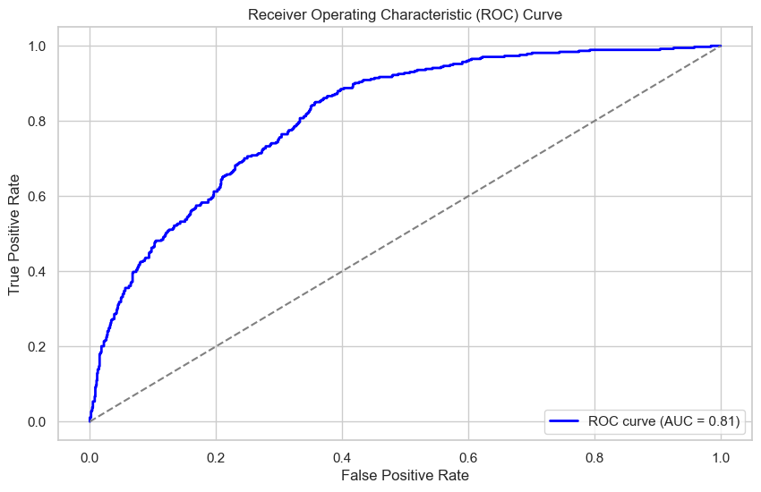

```python
y_prob = xgb_clf.predict_proba(x_test)[:,1] #predict the probability of the target variable using the test data to get the roc curve
fpr, tpr, thresholds = roc_curve(y_test, y_prob)
auc = roc_auc_score(y_test, y_prob)
# Plot ROC curve
plt.figure(figsize=(10, 6))
plt.plot(fpr, tpr, color='blue', lw=2, label='ROC curve (AUC = %0.2f)' % auc)
plt.plot([0, 1], [0, 1], color='gray', linestyle='--')
plt.xlabel('False Positive Rate')
plt.ylabel('True Positive Rate')
plt.title('Receiver Operating Characteristic (ROC) Curve')
plt.legend(loc='lower right')
plt.show()
```

the Decision Tree, Random Forest and XGBoost, exhibit the same AUC score of 0.81, it suggests that they perform similarly in terms of discriminating between positive and negative classes. In other words, both models are equally effective at ranking the instances correctly, distinguishing between churn and non-churn instances. However, it's essential to note that although the AUC scores are the same, the underlying mechanisms of the models differ significantly.

**Hyper-tunning of the XGBoost classifier** :

```python
# Define the parameter grid
param_grid = {
    'n_estimators': [50, 100],
    'max_depth': [3, 6],
    'learning_rate': [0.1, 0.01]
}


# Create XGBoost classifier
xgb_clf = xgb.XGBClassifier(random_state=42)

# Create GridSearchCV instance
grid_search = GridSearchCV(estimator=xgb_clf, param_grid=param_grid, scoring='roc_auc', cv=5, verbose=1)

# Fit the GridSearchCV object to the data
grid_search.fit(x_train, y_train)

# Get the best parameters and best AUC score
best_params = grid_search.best_params_
best_auc = grid_search.best_score_

print("Best parameters:", best_params)
print("Best AUC score:", best_auc)
```

```
Fitting 5 folds for each of 8 candidates, totalling 40 fits
Best parameters: {'learning_rate': 0.1, 'max_depth': 3, 'n_estimators': 50}
Best AUC score: 0.8498202239911894
```

- The XGBoost model achieved the highest AUC score, followed by the Random Forest model, with the Decision Tree model trailing behind.
- The Decision Tree model attained an AUC score of approximately 0.830, indicating reasonable discriminative ability in distinguishing between instances but falling short compared to the Random Forest and XGBoost models. The Random Forest model improved upon the Decision Tree's performance, achieving a higher AUC score of approximately 0.841, while the XGBoost model outperformed both with an AUC score of approximately 0.850. This indicates that the XGBoost model is the most effective at capturing complex patterns in the data and making accurate predictions, followed by the Random Forest model, while the Decision Tree model exhibits the lowest performance among the three models.